# MTH6139 Time Series

Coursework 1

Maiesha Siddika

Spring term 2025

## 0. Libraries used

```
- **tidyverse**: data manipulation and visualisation
- **tsibbledata**: for taylor_30_min electricity demand dataset
- **prophet**: Meta's forecasting model
- **tseries**: for ADF stationarity test
- **lmtest** for Breusch-Pagan heteroskedasticity test
- **forecast** for displaying forecasts
```

## 1. Data Description and Exploratory Data Analysis

### 1.1 Data Overview

This dataset contains half-hourly electricity demand records for England and Wales. There are a total of 4032 observations. This is a univariate time series model.

- **Data:** Half-hourly electricity demand records for England and Wales
- **Measure:** Electricity demand in Megawatts (MW)
- **Time Range:** Monday 5 June 2000 to Sunday 27 August 2000
- **Frequency:** 48 observations per day (half-hourly intervals)
- **Total Observations:** 4,032
- **Data Type:** Univariate time series
- **Source:** “tsibbledata” R library

```r
#load data
data(taylor)


# Formatting data correctly
start_time <- as.POSIXct("2000-06-05 00:00:00")
taylor_30_min <- data.frame(
  ds = seq(start_time, by = "30 min", length.out = length(taylor)),
  y = as.numeric(taylor)
)
```

```r
#checking class
class(taylor_30_min)
```

```
## [1] "data.frame"
```

We can see it’s already a data frame so we don’t have to do anything.

```r
# This returns the first few rows
head(taylor_30_min)
```

```
##                    ds     y
## 1 2000-06-05 00:00:00 22262
## 2 2000-06-05 00:30:00 21756
## 3 2000-06-05 01:00:00 22247
## 4 2000-06-05 01:30:00 22759
## 5 2000-06-05 02:00:00 22549
## 6 2000-06-05 02:30:00 22313
```

```r
# renaming columns
taylor_df <- taylor_30_min
names(taylor_df) <- c("ds", "y")
```

```r
# Display first few rows
head(taylor_df)
```

```
##                    ds     y
## 1 2000-06-05 00:00:00 22262
## 2 2000-06-05 00:30:00 21756
## 3 2000-06-05 01:00:00 22247
## 4 2000-06-05 01:30:00 22759
## 5 2000-06-05 02:00:00 22549
## 6 2000-06-05 02:30:00 22313
```

### 1.2 Summary Statistics

```r
# Create a proper ts object
Electricity_data <- ts(taylor_30_min,
                       frequency = 48,
                       start = c(2000, 6, 5))
```

```r
# This gives a quick statistical overview of the data
summary(Electricity_data)
```

```
##        ds                  y
##  Min.   :960159600   Min.   :18640
##  1st Qu.:961973550   1st Qu.:24272
##  Median :963787500   Median :29485
##  Mean   :963787500   Mean   :29617
##  3rd Qu.:965601450   3rd Qu.:35132
##  Max.   :967415400   Max.   :38777
```

We can see the minimum value is 18640 MW and the highest electricity usage is 38777.

```r
#This displays the no.elements in a dataset
length(Electricity_data)
```

```
## [1] 8064
```

```r
frequency(Electricity_data)
```

```
## [1] 48
```

This means there are 48 observations a day, which makes sense as observations are taken every 30minutes and in a 24 hour day there are 24*2 = 48 observations.

```r
start(Electricity_data)
```

```
## [1] 2000    6
```

```r
end(Electricity_data)
```

```
## [1] 2084    5
```

```r
#This is the number of days the data spans over.
length(Electricity_data)/48
```

```
## [1] 168
```

### 1.3 Plots and Visualisations

Instead of plotting the entire time series we plot 2 weeks of data as it would be difficult to see peaks, troughs and seasonality if all the time series data was condensed on 1 plot.

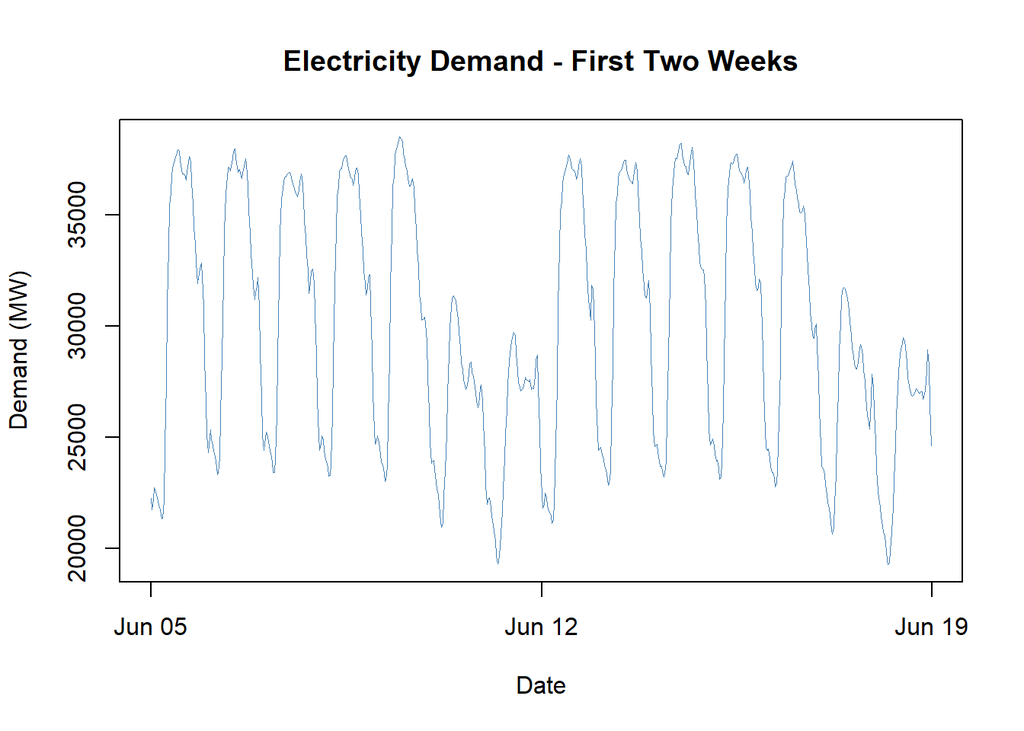

```r
first_2_weeks <- taylor_df[1:(14*48), ]

# Plot
plot(first_2_weeks$ds, first_2_weeks$y,
     type = "l",
     main = "Electricity Demand - First Two Weeks",
     ylab = "Demand (MW)",
     xlab = "Date",
     col = "steelblue",
     lwd = 0.8)
```

Jun 05, Jun 12, Jun 19 correspond with Monday. So here we can see that the peaks correspond to day electricity use and the troughs correspond to night electricity usage. Similarly, the smaller two peaks show Saturday and Sunday have lower electricity usage compared with the weekdays.

```r
dim(first_2_weeks)
```

```
## [1] 672   2
```

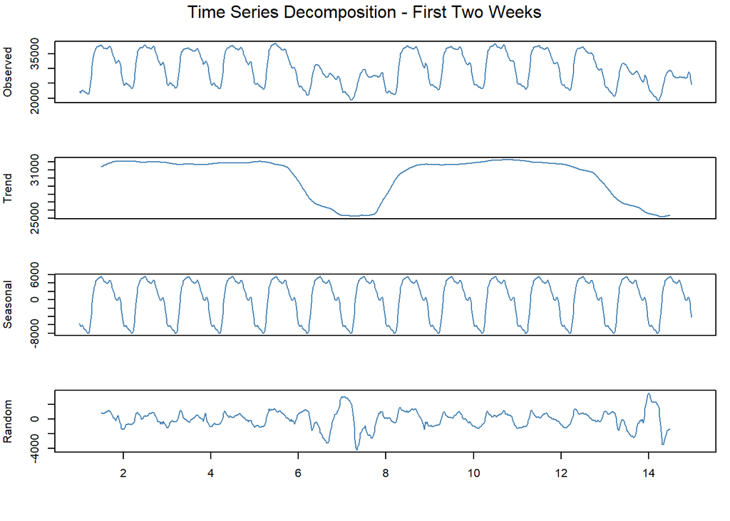

```r
# Create time series from first_2_weeks dataframe
first_two_weeks_ts <- ts(first_2_weeks$y,
                         frequency = 48,
                         start = 1)

# Decompose
decomp_2weeks <- decompose(first_two_weeks_ts, type = "additive")

# Plot
par(mfrow = c(4, 1), mar = c(3, 4, 1, 1), oma = c(2, 0, 2, 0))
plot(decomp_2weeks$x, col = "steelblue", ylab = "Observed", xlab = "", xaxt = "n")
plot(decomp_2weeks$trend, col = "steelblue", ylab = "Trend", xlab = "", xaxt = "n")
plot(decomp_2weeks$seasonal, col = "steelblue", ylab = "Seasonal", xlab = "", xaxt = "n")
plot(decomp_2weeks$random, col = "steelblue", ylab = "Random", xlab = "Time")


mtext("Time Series Decomposition - First Two Weeks", outer = TRUE, line = 0.5)
```

Here we can see the time series decomposed. The trend isn’t linear like we have seen before, it seems to mirrors the weekday, weekend trend of electricity demand. Seasonality makes sense here as this is electricity data where usage is higher during the weekdays and the daytime.

### 1.4 Trend Analysis - Linear Regression

Although we have seen the trend isn’t linear looking at all it is still worth it to look at linear regression to see if there is a wider overall upward or download trend in the data.

```r
# Add  time index
taylor_df$time_index <- 1:nrow(taylor_df)


head(taylor_df)
```

```
##                    ds     y time_index
## 1 2000-06-05 00:00:00 22262          1
## 2 2000-06-05 00:30:00 21756          2
## 3 2000-06-05 01:00:00 22247          3
## 4 2000-06-05 01:30:00 22759          4
## 5 2000-06-05 02:00:00 22549          5
## 6 2000-06-05 02:30:00 22313          6
```

```r
#linear regression
trend_model <- lm(y ~ time_index, data = taylor_df)
summary(trend_model)
```

```
##
## Call:
## lm(formula = y ~ time_index, data = taylor_df)
##
## Residuals:
##      Min       1Q   Median       3Q      Max
## -10895.6  -5379.1    -16.7   5595.7   8898.0
##
## Coefficients:
##               Estimate Std. Error t value Pr(>|t|)
## (Intercept)  3.030e+04  1.750e+02 173.188  < 2e-16 ***
## time_index  -3.397e-01  7.515e-02  -4.521 6.34e-06 ***
## ---
## Signif. codes:  0 '***' 0.001 '**' 0.01 '*' 0.05 '.' 0.1 ' ' 1
##
## Residual standard error: 5554 on 4030 degrees of freedom
## Multiple R-squared:  0.005045,   Adjusted R-squared:  0.004798
## F-statistic: 20.44 on 1 and 4030 DF,  p-value: 6.343e-06
```

```r
# Calculate average growth per day (48 time periods)
daily_growth <- coef(trend_model)[2] * 48
cat("Average daily growth:", round(daily_growth, 2), "MW per day\n")
```

```
## Average daily growth: -16.31 MW per day
```

We can see that there is a small negative growth in the long term by araound 16 MW per day.

### 1.4 Hypothesis Tests

- Prophet does not require stationarity or heteroskedasticity tests as it handles these through its flexible trend and seasonality components. However, for completeness:
  - Stationarity tests: Augmented Dickey-Fuller (ADF) test checks if series has unit root
  - Heteroskedasticity tests: Breusch-Pagan test checks if variance changes over time

```r
adf.test(Electricity_data[,2])  # Stationarity test
```

```
##
##  Augmented Dickey-Fuller Test
##
## data:  Electricity_data[, 2]
## Dickey-Fuller = -14.104, Lag order = 15, p-value = 0.01
## alternative hypothesis: stationary
```

```r
bptest(lm(Electricity_data ~ time(Electricity_data[,2])))  # Heteroskedasticity test
```

```
##
##  studentized Breusch-Pagan test
##
## data:  lm(Electricity_data ~ time(Electricity_data[, 2]))
## BP = 2452, df = 1, p-value < 2.2e-16
```

## 2. Data Preparation for Prophet

### 2.1 Intro

- Prophet requires a specific data frame format with columns:
  - ds: time-stamp (date or datetime)
  - y:numeric value to forecast

    We did this earlier on with “taylor_df”

```r
head(taylor_df)
```

```
##                    ds     y time_index
## 1 2000-06-05 00:00:00 22262          1
## 2 2000-06-05 00:30:00 21756          2
## 3 2000-06-05 01:00:00 22247          3
## 4 2000-06-05 01:30:00 22759          4
## 5 2000-06-05 02:00:00 22549          5
## 6 2000-06-05 02:30:00 22313          6
```

### 2.2 Check for missing values and outliers

- check missing values : Prophet has no problem with missing data anyway as it would interpolate the trend and seasonality over the missing gaps.
- check anomalies + get rid of if need be (only extreme ones).
- data transformation if variance increases with level.

```r
missing_count <- sum(is.na(taylor_df$y))
cat("Missing values:", missing_count, "\n")
```

```
## Missing values: 0
```

We have no missing values! If we did we could use interpolation or mean imputation to fill the NaN values.

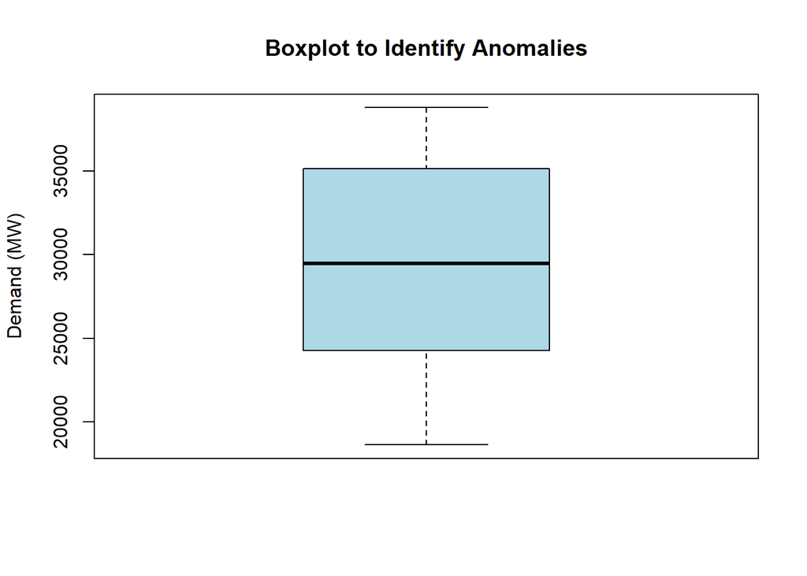

```r
# Check for anomalies (extreme values)
boxplot(taylor_df$y, main = "Boxplot to Identify Anomalies",
        ylab = "Demand (MW)", col = "lightblue")
```

```r
# Calculate z-scores to identify extreme outliers
z_scores <- scale(taylor_df$y)

extreme_outliers <- which(abs(z_scores) > 4)
cat("\nPotential extreme outliers (|z| > 4):", length(extreme_outliers), "\n")
```

```
##
## Potential extreme outliers (|z| > 4): 0
```

In electricity data, outliers often contain valuable information as these spikes represent events such as Heat waves (AC usage), cold periods (Heating) or major events (World Cup, Holidays). Hence we don’t get rid of them. Removing them can bias our forecast. Additionally, Prophet is robust to outliers so often we don’t need to get rid of them.

From the boxplot and looking at z scores there are no extreme outliers.

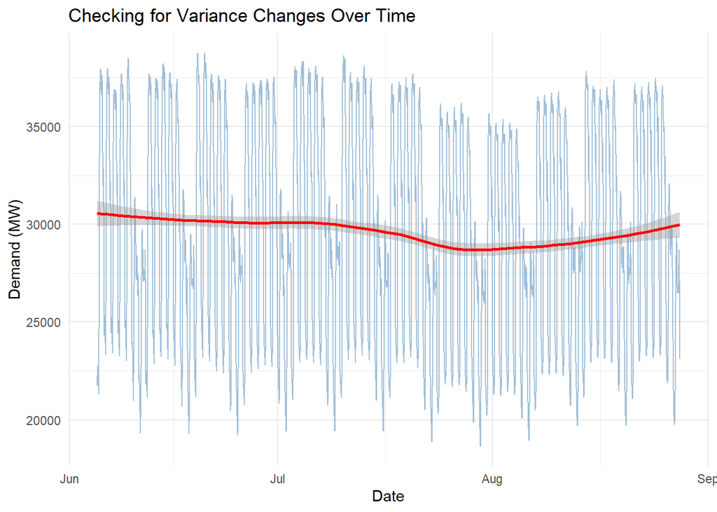

```r
# Check if variance increases with level
ggplot(taylor_df, aes(x = ds, y = y)) +
  geom_line(color = "steelblue", alpha = 0.5) +
  geom_smooth(method = "loess", color = "red") +
  labs(title = "Checking for Variance Changes Over Time",
       x = "Date", y = "Demand (MW)") +
  theme_minimal()
```

To see if variance increases with mean - we want to look for a fan or cone shape where fluctuations get wider as values increase. Normally, if it does have this shape, we should do a Log transform on the dataset. However as we are going to use the prophet model which doesn’t require constant variance, we don’t have to do anything.

### 2.3 Train Test Split

We conduct a train test split where we split the dataset into “training data” where we fit the model and “testing data” where we test our model + make forecasts.

```r
train_pct <- 0.8
split_idx <- floor(nrow(taylor_df) * train_pct)

train_data <- taylor_df[1:split_idx, ]
test_data <- taylor_df[(split_idx + 1):nrow(taylor_df), ]
```

## 3. Prophet Description + Model Implementation

### 3.1 Mathematical Background

Prophet is a model for forecasting time series based on an additive mode. It decomposes time series into three main components:

$$y(t) = g(t) + s(t) + h(t) +
\epsilon_t$$

Where:

- $g(t)$: Trend component (piecewise linear or logistic growth)
- $s(t)$: Seasonal component (Fourier series)
- $h(t)$: Holiday effects
- $\varepsilon_t$: Error term

Seasonality is modelled using Fourier series:

$$s(t) = \sum_{n=1}^{N} \left( a_n
\cos\left(\frac{2\pi n t}{P}\right) + b_n \sin\left(\frac{2\pi n
t}{P}\right) \right)$$

- $N$ = number of Fourier terms
- $P$ = period or the length of 1 full cycle (e.g 24 hours for daily data)
- $a_n, b_n$ = Fourier coefficients , these are weights that the model learns for each sin and cosine terms. This then determines the amplitude and phase of the seasonal pattern.

**Advantages of Prophet:**

- Handles missing data automatically
- Robust to outliers
- No need for stationarity transformations
- Intuitive parameters for non-experts
- Fast fitting even for large datasets

**Limitations:**

- May not capture complex long-range dependencies
- Assumes additive seasonality (can use multiplicative with log transform)
- Less suitable for very high-frequency data with multiple seasonalities

### 3.2 Implementation

The following shows what each parameter in the prophet model means.

- **yearly.seasonality = FALSE/TRUE** : yearly patterns
- **weekly.seasonality = FALSE/TRUE** : Considers weekday vs weekend patterns
- **daily.seasonality = TRUE/FALSE** : Patterns within each day (morning vs night)
- **seasonality.mode = ‘additive’** : Seasonal effects add to trend (vs multiplicative where they scale with trend)
- **changepoint.prior.scale = 0.1**: How flexible the trend it:
  - Lower (0.01) = smoother, less responsive to changes
  - Higher (0.05) = more wiggly, responsive to changes
  - 0.1 = moderately flexible trend
- **seasonality.prior.scale = 15**: How strong seasonal patterns can be
  - Lower (1-5) = weaker, smoother seasonality
  - Higher (10-20) = stronger, more pronounces seasonality
  - 15 = allows strong daily/weekly patterns (good for electricity)

```r
#Prophet model
basic_model <- prophet(yearly.seasonality = FALSE,
                          weekly.seasonality = TRUE,
                          daily.seasonality = FALSE,
                          seasonality.mode = 'additive',
                          changepoint.prior.scale = 0.1,
                          seasonality.prior.scale = 15,
                          interval.width = 0.95)

# Add custom daily seasonality
basic_model <- add_seasonality(basic_model,
                                   name = 'daily',
                                   period = 1,
                                   fourier.order = 25)  # More flexible

# Fit the model
basic_model <- fit.prophet(basic_model, train_data)
```

## 4. Forecasting

In this section we will generate predictions for our model and plot our predicted time forecasts against our actual values.

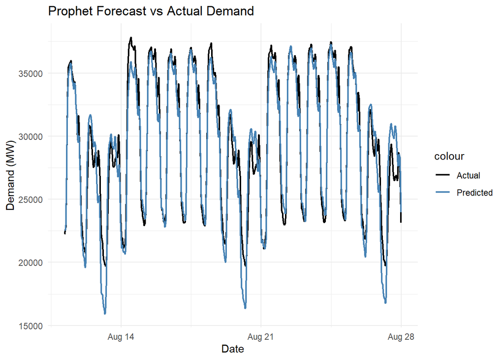

```r
future <- make_future_dataframe(basic_model, periods = nrow(test_data), freq = 1800)

# Generate forecasts using predict()
forecast <- predict(basic_model, future)

# Extract test predictions
test_predictions <- forecast %>%
  slice((nrow(train_data) + 1):nrow(forecast)) %>%
  select(ds, yhat, yhat_lower, yhat_upper)

# Add predictions to test data
test_results <- test_data
test_results$yhat <- test_predictions$yhat
test_results$yhat_lower <- test_predictions$yhat_lower
test_results$yhat_upper <- test_predictions$yhat_upper

#  Actual vs Predicted plot
ggplot(test_results, aes(x = ds)) +
  geom_line(aes(y = y, color = "Actual"), size = 0.8) +
  geom_line(aes(y = yhat, color = "Predicted"), size = 0.8) +
  scale_color_manual(values = c("Actual" = "black", "Predicted" = "steelblue")) +
  labs(title = "Prophet Forecast vs Actual Demand",
       x = "Date", y = "Demand (MW)") +
  theme_minimal()
```

We can see that our “Actual” line and “Predicted” line closely mirror each other (on the testing period) showing that our predicted line/ model is quite good. However, this is a short test period and not a very rigorous way of analysing our predictions. So let’s look at a more systematic way of evaluating.

## 5. Model Evaluation

$$\textbf{MAE (Mean Absolute Error)} =
\frac{1}{n}\sum_{i=1}^{n} |y_i - \hat{y}_i|$$

$$\textbf{RMSE (Root Mean Square Error)} =
\sqrt{\frac{1}{n}\sum_{i=1}^{n} (y_i - \hat{y}_i)^2}$$

- **MAE** = x: means “on average, your forecast if off by”x” MW
- **RMSE** penalises larger errors more heavily

**Residuals over Time Plot**

- We want residuals and points to be randomly scattered around the zero line with no pattern visible as this indicates constant variance and no time-based correlation.
- If residuals fan out or funnel in - this suggests that the model;s accuracy changes over time which is not good.
- If there is an upwards or downwards trend in the residuals this indicates the model is missing a linear time component which is again not good.

**Ljung Box test for Residuals**

H0: The residuals are independent and identically distributed (white noise)

H1: The residuals exhibit autocorrelation (when there are correlations between the lagged versions basically)

This evaluates whether the residuals are white noise : which is what we want.

```r
# Calculate simple error metrics
test_results$error <- test_results$y - test_results$yhat
test_results$abs_error <- abs(test_results$error)

mae <- mean(test_results$abs_error)
rmse <- sqrt(mean(test_results$error^2))

cat("MAE:", round(mae, 2), "MW\n")
```

```
## MAE: 1099.72 MW
```

```r
cat("RMSE:", round(rmse, 2), "MW\n")
```

```
## RMSE: 1491.39 MW
```

The average of the time series data is 29,617 MW and the MAE is 1099.72 MW. So on average we are off by around 3.7%. In energy forecasting an error under 5% is decent - not amazing however.

The RMSE is higher at 1491.39 indicating that whilst our predictions are generally accurate we are predicting some outliers. The next step in improving the model would be to investigate where the error spike.

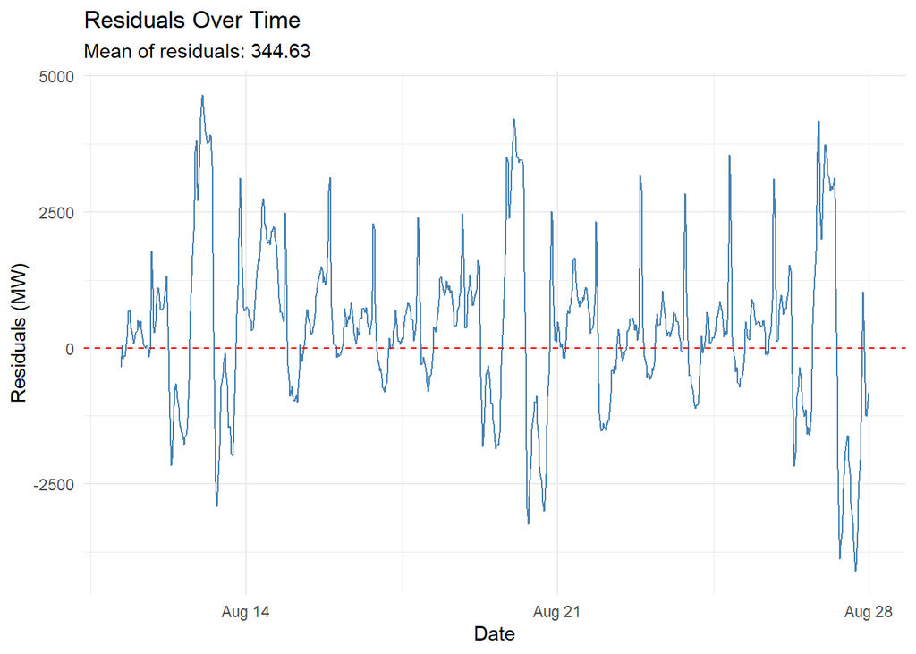

```r
# Calculate residuals
test_results$residuals <- test_results$y - test_results$yhat

# Residuals over time
ggplot(test_results, aes(x = ds, y = residuals)) +
  geom_line(color = "steelblue") +
  geom_hline(yintercept = 0, linetype = "dashed", color = "red") +
  labs(title = "Residuals Over Time",
       subtitle = paste("Mean of residuals:", round(mean(test_results$residuals), 2)),
       x = "Date", y = "Residuals (MW)") +
  theme_minimal()
```

```r
# Check if residuals are white noise (Ljung-Box test)
Box.test(test_results$residuals, lag = 48, type = "Ljung-Box")
```

```
##
##  Box-Ljung test
##
## data:  test_results$residuals
## X-squared = 5260.8, df = 48, p-value < 2.2e-16
```

Looking at the Ljung-Box test, we want a high p value (p>0.05) indicating that residuals are independent and all signals/ patterns have been captured. However we have a very small p value that is almost 0 and a very high X-squared statistic. This shows that our model misses temporal dynamics/ dependencies over time. Additionally, if we look again at our residuals over time plot, there does seem to be a pattern - albeit hard to spot. Hence we could add different components or test different models in the future.

## 6. Discussion of Results

In conclusion, we loaded in our Taylor_30 dataset, looked at summary statistics to get a brief overview of the data and plotted it to see patterns. We then formatted the dataset for the “prophet” model and made forecasts. We plotted the forecasts against actual values and this plot looked promising. Additionally, the MAE (1099.72MW, ~3.7% relative error) and RMSE (1491.39 MW) were decent and not too alarming which suggested the model captured the overall level/ behaviour of the data well. However after further analysis, particularly looking at the Ljung Box Test (which returned a very small p value near 0) and residuals over time plot we can see that some temporal dependancies have been missed.

To address these shortcoming, I would look at the following topics for the future.

- Use different models: Prophet handles seasonality, but there are other models that explicitly model time dependencies, such as SARIMA (Seasonal ARIMA) or LSTM network
- Feature Engineering: Add additional regressors that capture:
  - Lag variables (demand 24 hours ago, 48 hours ago, and 7 days ago)
  - Calendar effects (hour of day, day of week, holiday indicators)
- Ensemble Approach: Combine Prophet’s strength at capturing trend and seasonality with a secondary model (e.g., ARIMA on the residuals) to correct the autocorrelation patterns left behind.
- Cross-Validation: Implement time series cross-validation to ensure the model performs consistently across different seasons and time periods, not just on the test set as a whole.

By implementing these improvements, we can build a model that predicts the right value on average and can also capture the rhythm and dependencies inherent in energy time series data.